# Lab 8, Fish Functions

Author

Danny Morehouse

The goal of this lab is learn more about exploring missing data and writing modular code.

## The Data

This lab’s data concerns mark-recapture data on four species of trout from the Blackfoot River outside of Helena, Montana. These four species are **rainbow trout (RBT)**, **westslope cutthroat trout (WCT)**, **bull trout**, and **brown trout**.

Mark-recapture is a common method used by ecologists to estimate a population’s size when it is impossible to conduct a census (count every animal). This method works by *tagging* animals with a tracking device so that scientists can track their movement and presence.

## Data Exploration

The measurements of each captured fish were taken by a biologist on a raft in the river. The lack of a laboratory setting opens the door to the possibility of measurement errors.

**1a. Let’s look for missing values in the dataset. Output ONE table that answers BOTH of the following questions:**

- **How many observations have missing values?**
- **What variable(s) have missing values present?**

**You should use `across()`!**

```r
# 1796 missing observations, all within 'weight'
# Asked ChatGPT for help because the basic pipe wasn't producing the proper result. I was able to get the missing observations, but couldn't figure out how to return the missing_variables. Not only did it provide the recommendation to use the other pipe, but it suggested adding rowSums after across() to pair the 2 functions together

fish_data %>%
  summarize(missing_observations = sum(across(everything(), ~is.na(.)) %>% rowSums() > 0),
            missing_variables = list(names(which(colSums(is.na(.)) > 0))))
```

```
  missing_observations missing_variables
1                 1796            weight
```

**1b. Using `map_int()`, produce a nicely formatted table of the number of missing values for each variable in the `fish` data that displays the same information as 1a**

```r
# Searched map_int() function to see where to input the proper variables, used the same sum(is.na) entry from above
# Knew I had to use the names from missing values, but didn't know what function to start with, ChatGPT provided assistance with the 'tibble' function

missing_values <- map_int(fish_data, ~sum(is.na(.)))

missing_values_mapping <- tibble(variable = names(missing_values),
                               missing_count = missing_values)
```

**2. Create ONE thoughtful visualization that explores the frequency of missing values across the different years, sections, and trips.**

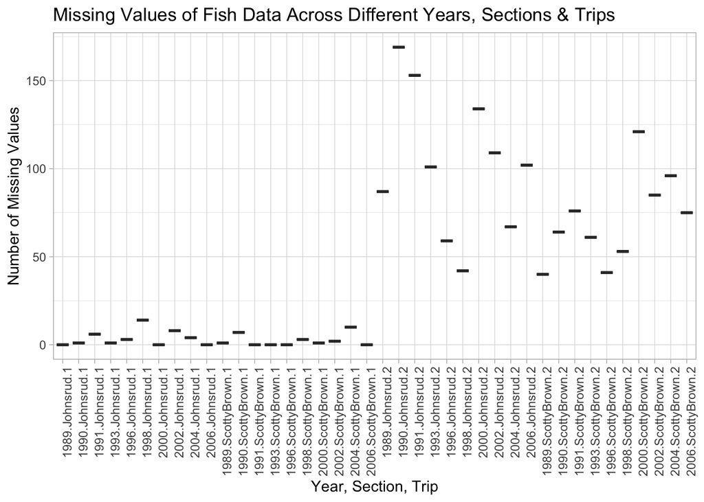

```r
# Knew how to group the variables, but was extremely confused on how to make a visualization combining the 3 variables on one axis. I was comfortable making a boxplot, so I asked ChatGPT how to combine 3 variables on one axis - which returned interaction()
# Once again, I apologize for the excessive use of AI assistance, i'm trying to use it only as a last ditch effort if I can't figure it out with my own experience

new_fish_data <- fish_data |>
  mutate(missing_count = rowSums(is.na(across(everything())))) #Make variable for missing data

missing_visualization <- new_fish_data |>
  group_by(year, section, trip) |> #Group by 3 variables
  summarize(missing_values = sum(missing_count))


missing_visualization |>
  ggplot(aes(x = interaction(year, section, trip), y = missing_values)) +
  geom_boxplot(fill = "black") +
  labs(x = "Year, Section, Trip",
       y = "Number of Missing Values",
       title = "Missing Values of Fish Data Across Different Years, Sections & Trips") +
  theme_light() +
  theme(axis.text.x = element_text(angle = 90, hjust = 1))
```

## Rescaling the Data

If I wanted to rescale every quantitative variable in my dataset so that they only have values between 0 and 1, I could use this formula:

$$y_{scaled} = \frac{y_i - min\{y_1, y_2,..., y_n\}}{max\{y_1, y_2,..., y_n\}
- min\{y_1, y_2,..., y_n\}}$$

I might write the following `R` code to carry out the rescaling procedure for the `length` and `weight` columns of the `BlackfoorFish` data:

```r
fish <- fish |>
  mutate(length = (length - min(length, na.rm = TRUE)) /
           (max(length, na.rm = TRUE) - min(length, na.rm = TRUE)),
         weight = (weight - min(weight, na.rm = TRUE)) /
           (max(weight, na.rm = TRUE) - min(length, na.rm = TRUE)))
```

This process of duplicating an action multiple times can make it difficult to understand the intent of the process. *Additionally, it can make it very difficult to spot mistakes.*

**3. What is the mistake I made in the above rescaling code?**

When you find yourself copy-pasting lines of code, it’s time to write a function, instead!

**4. Transform the repeated process above into a `rescale_01()` function. Your function should…**

- **… take a single vector as input.**
- **… return the rescaled vector.**

```r
# Took the start of the rescale function from the W12 video project, not sure if my following code is correct. I got a response for the test code below but I'm not sure if it is correct.

#rescale_01 <- function(x) {
  #((x - min(x)) / (max(x) - min(x)))
  #if(!is.numeric(x))
    #stop()
 # if (length(x) <= 1)
    #stop()
#}

#Code before asking ChatGPT what was wrong

rescale_01 <- function(x) {
  if (!is.numeric(x)) {
    stop("Input must be numeric.")
  }

  if (length(x) <= 1) {
    stop("Input must have more than one element.")
  }

  # Remove NAs from the data when calculating min and max
  min_val <- min(x, na.rm = TRUE)
  max_val <- max(x, na.rm = TRUE)

  # Check if all values are NA
  if (is.infinite(min_val) || is.infinite(max_val)) {
    stop("All values in the input are NA.")
  }

  # Rescale the input
  scaled_x <- (x - min_val) / (max_val - min_val)

  return(scaled_x)
}

# AI recommended adding the NA portions of the function to acknowledge the error message I was seeing...
  # Warning: no non-missing arguments to min; returning Inf[1] Inf
  # Warning: no non-missing arguments to max; returning -Inf[1] -Inf
```

**Efficiency**

Think about the efficiency of the function you wrote. Are you calling the **same** function multiple times? You might want to look into the `range()` function.

**5. Let’s incorporate some input validation into your function. Modify your previous code so that the function stops if …**

- **… the input vector is not numeric.**
- **… the length of the input vector is not greater than 1.**

**Modify Previous Code**

Do not create a new code chunk here – simply add these stops to your function above!

## Test Your Function

**6. Run the code below to test your function. Verify that the maximum of your rescaled vector is 1 and the minimum is 0!**

```r
# Asked ChatGPT for assistance when presented with an error message (listed above in function code)

x <- c(1:25, NA)

rescaled <- rescale_01(x)
min(rescaled, na.rm = TRUE)
```

```
[1] 0
```

```r
max(rescaled, na.rm = TRUE)
```

```
[1] 1
```

Next, let’s test the function on the `length` column of the `BlackfootFish` data.

**7. The code below makes a histogram of the original values of `length`. Add a plot of the rescaled values of `length`. Output your plots side-by-side, so the reader can confirm the only aspect that has changed is the scale.**

**Warning**

This will require you to call your `rescale_01()` function within a `mutate()` statement in order to create a `length_scaled` variable.

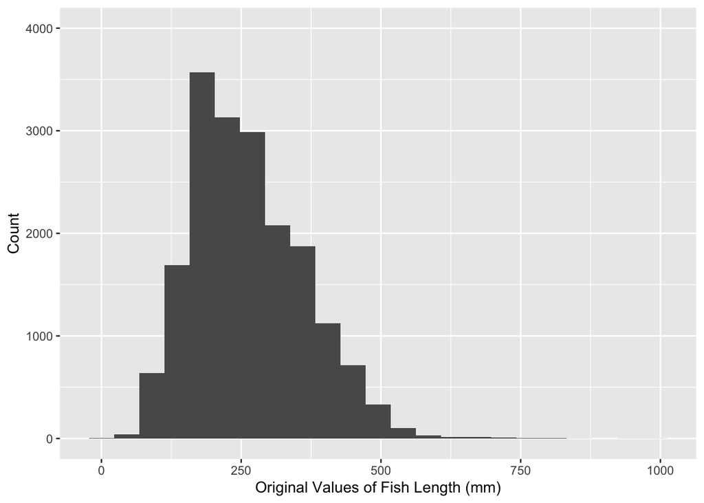

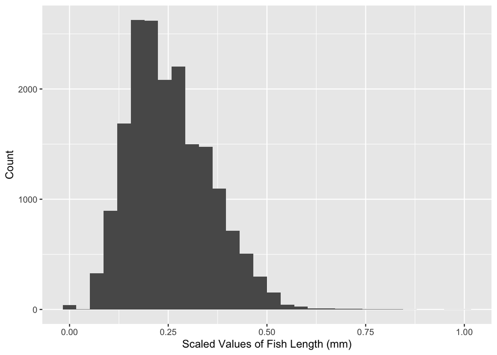

```r
# Need to modify the rescale function, won't produce a figure

fish_data |>
  ggplot(aes(x = length)) +
  geom_histogram(binwidth = 45) +
  labs(x = "Original Values of Fish Length (mm)",
       y = "Count") +
  scale_y_continuous(limits = c(0,4000))
rescaled <- fish_data |>
  mutate(length_scaled = rescale_01(length))

rescaled |>
  ggplot(aes(x = length_scaled)) +
  geom_histogram() +
  labs(x = "Scaled Values of Fish Length (mm)",
       y = "Count")
```

**Tip**

1. Set the y-axis limits for both plots to go from 0 to 4000 to allow for direct comparison across plots.
2. Pay attention to `binwidth`!
3. Use a Quarto code chunk option to put the plots side-by-side.

## Challenge: Use Variables within a Dataset

Suppose you would like for your `rescale()` function to perform operations on a **variable within a dataset**. Ideally, your function would take in a data frame and a variable name as inputs and return a data frame where the variable has been rescaled.

**8. Create a `rescale_column()` function that accepts two arguments:**

- **a dataframe**
- **the name(s) of the variable(s) to be rescaled**

**The body of the function should call the original `rescale_01()` function you wrote previously. Your solution MUST use one of the `rlang` options from class.**

**Tip**

If you are struggling with this task, I recommend looking back over the [data frame functions](https://r4ds.hadley.nz/functions.html#data-frame-functions) section of R for Data Science!

**9. Use your `rescale_column()` function to rescale *both* the `length` and `weight` columns.**

**Warning**

I expect that you carry out this process by calling the `rescale_column()` function only ONE time!